# ECON 413 Introduction to R

Erol Taymaz  
Department of Economics  
Middle East Technical University

1 March 2017

# Topics

- File organization
- R basics
- RStudio basics
- R as calculator
- Data structures

# File organization

- Organize files in directories
  - /econ413
    - /econ413/R files
    - /econ413/Data
    - /econ413/Figures
- Use consistent file names
  - 01 Economic growth data collect.R
  - 10 Economic growth descriptives.R
  - 20 Economic growth regressions.R
    - For our exercises, use **XX_YY.R** where **XX** is the exercise number, **YY** the student ID
- R code (R script) will be saved in /R files

# Installing R

- Base R and most R packages are available at cran.r-project.org
- There are thousands of R packages
  - A package for almost anything
  - More than one package for almost everything
- Commonly used packages
  - ggplot2
  - dplyr
  - data.table
  - plm
  - forecast

# Using R

- Basic vocabulary
  - **package**: Collections of R functions, data, and compiled code in a well-defined format
  - **library**: The directory where packages are stored
  - **workspace**: R working environment and includes all user-defined objects
  - **environment**: A place to store objects
  - **class**: A blueprint/template that describes the behavior/state that the object of its type can get
  - **object**: A specific/concrete realization of a class
    - Data objects
    - Functions

# Using R

**Objects**

- Data objects
  - Vectors
  - Matrices
  - Data frames (variables in column, observartions in rows)
- Functions
  - *functionName(arguments)*
  - mean(x, trim = 0, na.rm = FALSE)

# Using R

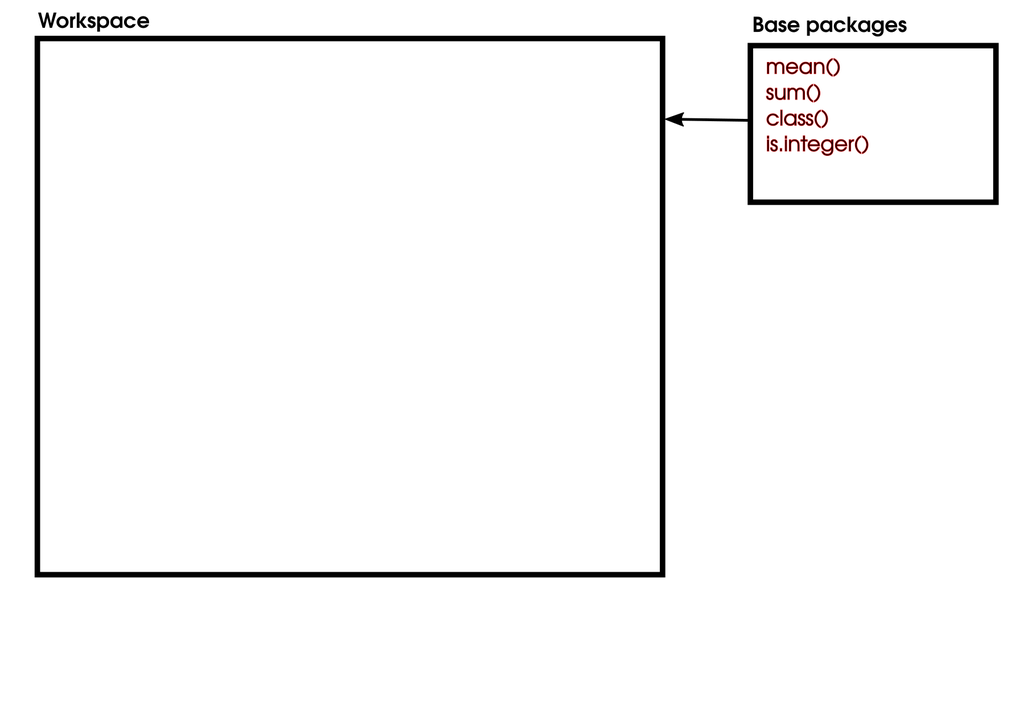

# Using R

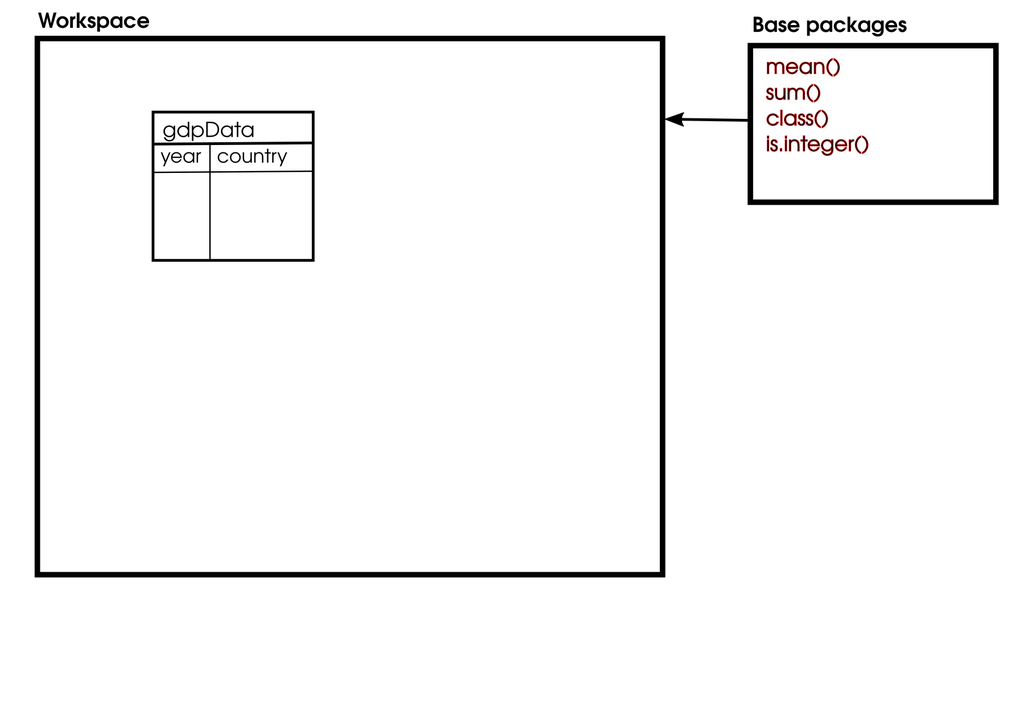

# Using R

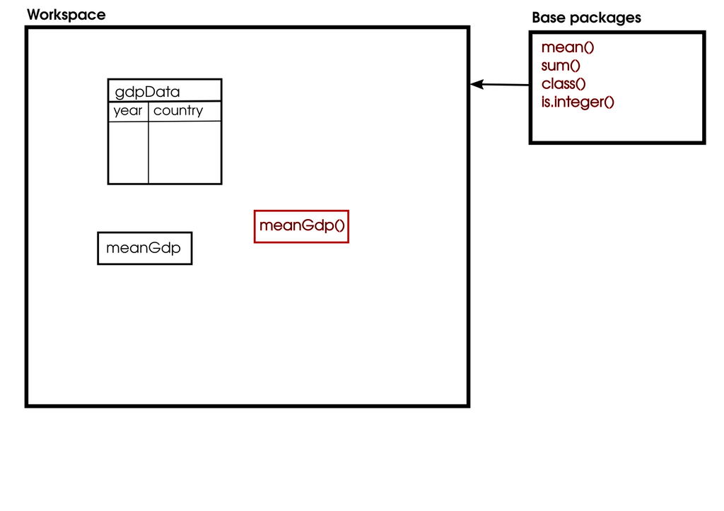

# Using R

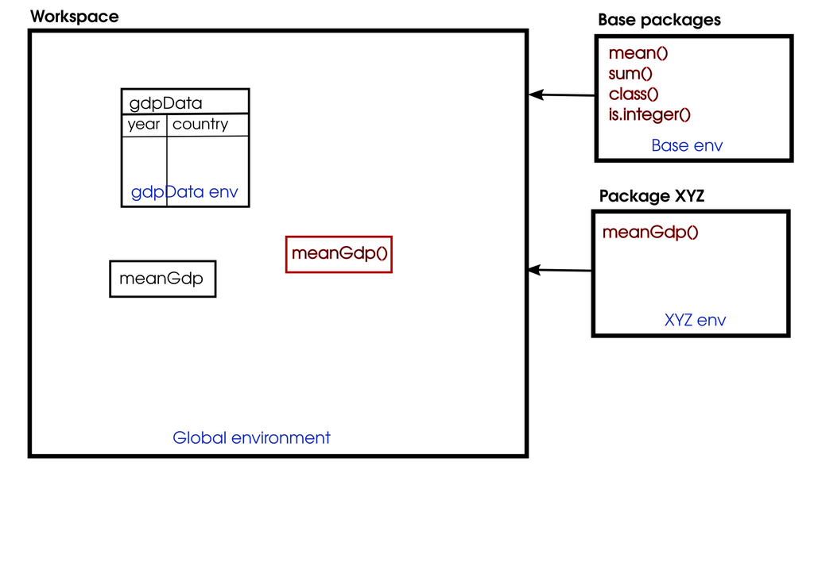

# Using R

- R is case sensitive!
- R is inconsistent in its naming conventions (unfortunately)
  - Be consistent: Use nouns for variables, verbs for functions
  - gnpData, gnp_data, gnp.data
  - getTrend, get_trend, get.trend

# Using RStudio

- R Studio

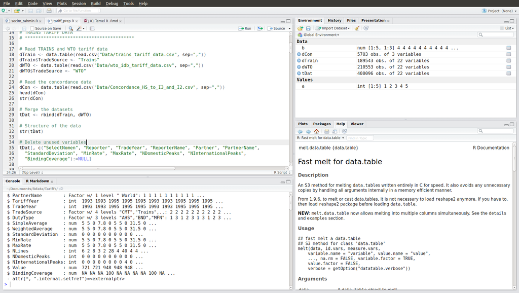

# RStudio shortcuts

- **Ctrl-1** and **Ctrl-2** to switch between script and console
- **Ctrl-Enter** to run the code

# Installing R packages

- Install the package into your computer

```r
install.packages(ggplot2)
```

- Update all packages/one package

```r
update.packages()
update.packages(ggplot2)
```

- Load the library (packages)

```r
library(ggplot2)   # Returns error
require(ggplot2)   # Returns warning
```

# R as calculator

- The most important functions
  - ? and ??
    - Stackoverflow - just Google
- Basic math
  - *, +, -, /, ^, %%, %/%
  - abs, sign, acos, asin, atan, atan2, sin, cos, tan, pi
  - ceiling, floor, round, trunc, signif
  - exp, log, log10, log2, sqrt
    - Check 1/0, 0/0
- Logical operators
  - &, |, !, xor
- Key operators
  - Assign: <- or = (use <-)
  - Sequence: :
  - Combine: c()

# R objects

**Everything in R is an object**

- Data

```r
a <- c(1:5)
a
```

```
## [1] 1 2 3 4 5
```

- Functions

```r
sum(a)
```

```
## [1] 15
```

```r
sum
```

```
## function (..., na.rm = FALSE)  .Primitive("sum")
```

- Graphs, too

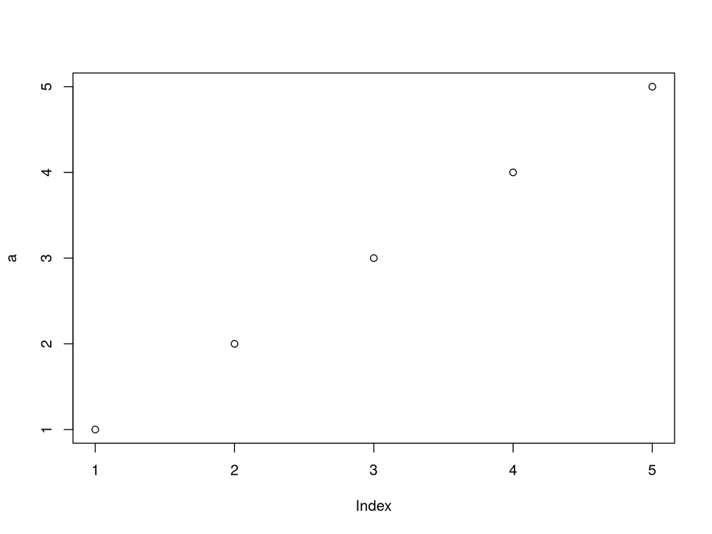

```r
b <- plot(a)
```

```r
b
```

- Results of functions can be stored in objects

```r
a <- rnorm(100)
b <- a + rnorm(100)
model_1 <- lm(a ~ b)
model_1
```

```
##
## Call:
## lm(formula = a ~ b)
##
## Coefficients:
## (Intercept)            b
##    -0.06659      0.50254
```

- Look at summaries

```r
summary(a)
```

```
##    Min. 1st Qu.  Median    Mean 3rd Qu.    Max.
## -2.1920 -0.7609 -0.2267 -0.1270  0.5273  2.8890
```

```r
summary(model_1)
```

```
##
## Call:
## lm(formula = a ~ b)
##
## Residuals:
##      Min       1Q   Median       3Q      Max
## -1.85112 -0.49000  0.09201  0.38376  2.82164
##
## Coefficients:
##             Estimate Std. Error t value Pr(>|t|)
## (Intercept) -0.06659    0.07262  -0.917    0.361
## b            0.50254    0.05216   9.635 7.49e-16 ***
## ---
## Signif. codes:  0 '***' 0.001 '**' 0.01 '*' 0.05 '.' 0.1 ' ' 1
##
## Residual standard error: 0.7235 on 98 degrees of freedom
## Multiple R-squared:  0.4865, Adjusted R-squared:  0.4812
## F-statistic: 92.84 on 1 and 98 DF,  p-value: 7.489e-16
```

- … and plots

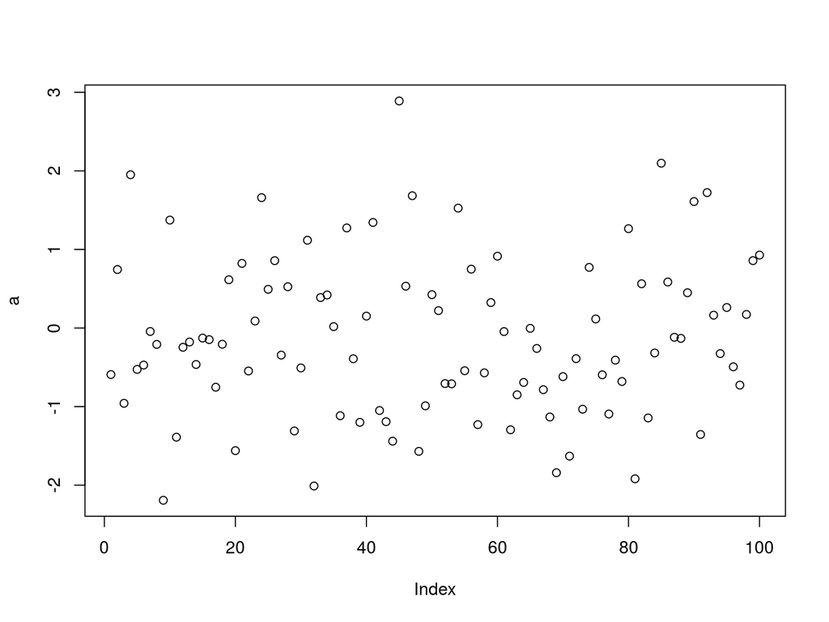

```r
plot(a)
```

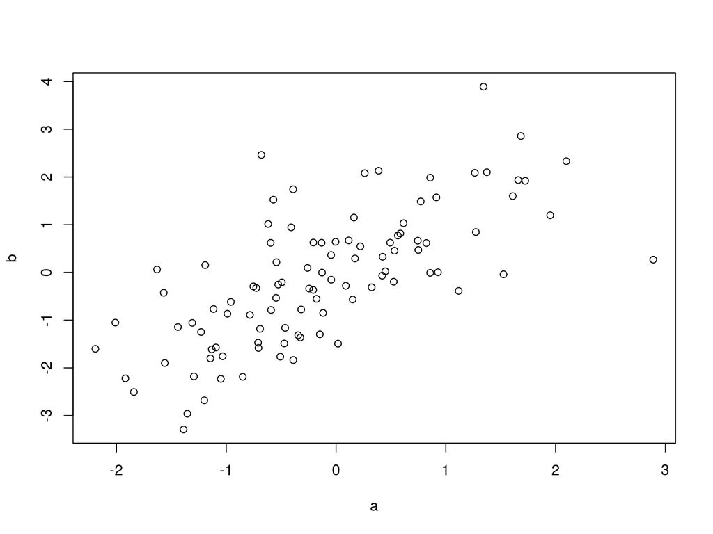

```r
plot(a, b)
```

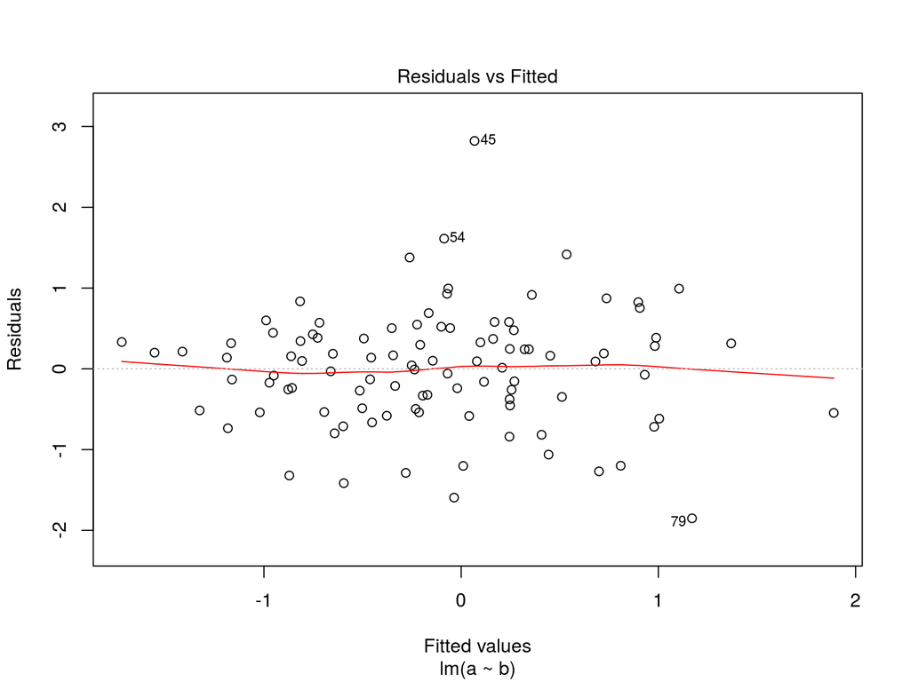

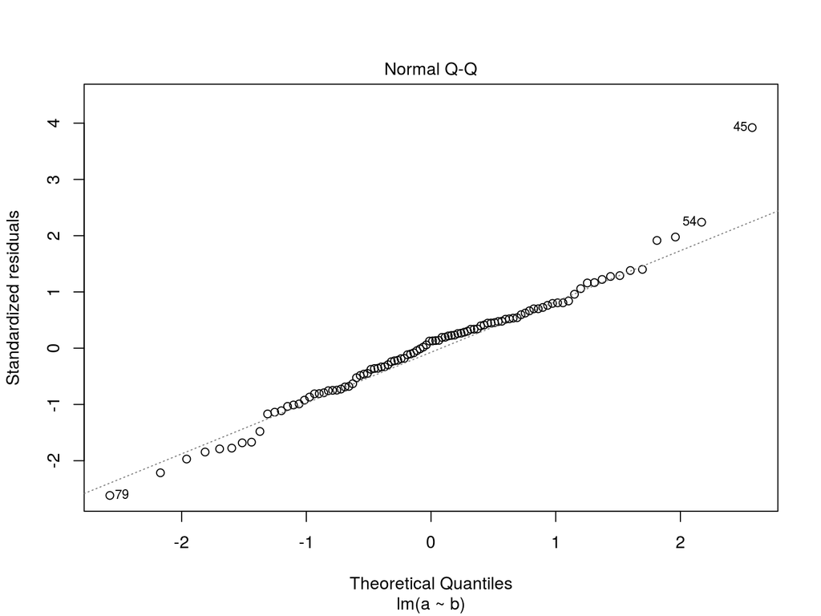

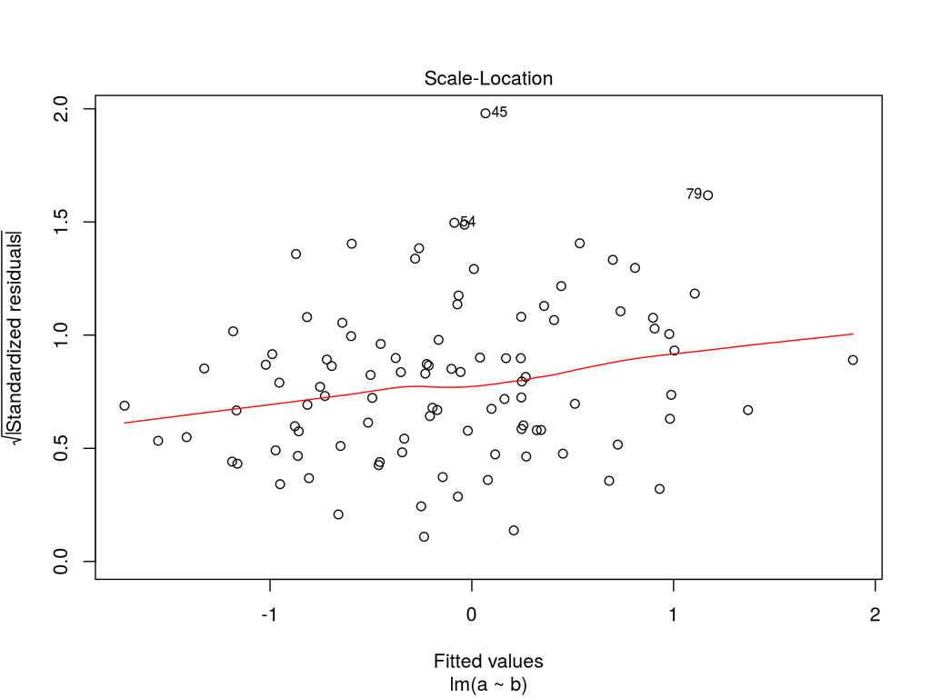

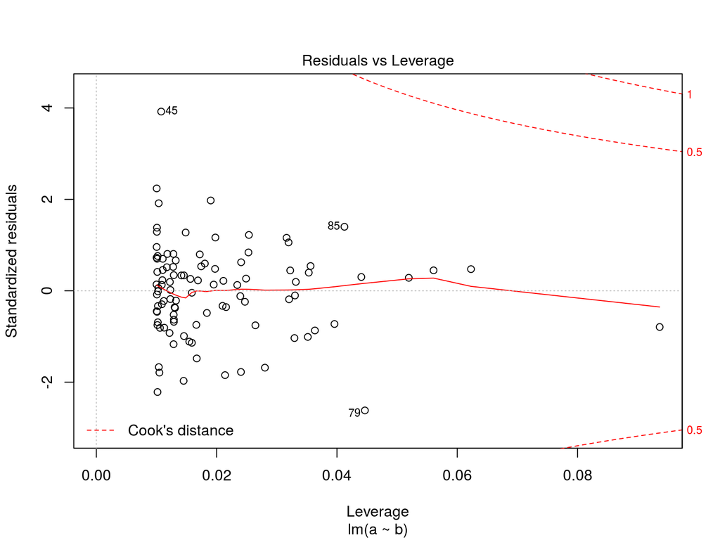

```r
plot(model_1)
```

- A function’s output depends on the object!

# Data modes

- Numeric
  - Integer
  - Double
- Character
- Logical

```r
a <- 5
b <- "a"
c <- TRUE
A <- c(1:5)
B <- c("a", "b", "c")
C <- c(T, F, T)
class(a)
```

```
## [1] "numeric"
```

```r
class(A)
```

```
## [1] "integer"
```

```r
class(b)
```

```
## [1] "character"
```

```r
class(B)
```

```
## [1] "character"
```

```r
class(c)
```

```
## [1] "logical"
```

```r
class(C)
```

```
## [1] "logical"
```

```r
is.numeric(C)
```

```
## [1] FALSE
```

```r
is.logical(C)
```

```
## [1] TRUE
```

```r
as.numeric(C)
```

```
## [1] 1 0 1
```

```r
C + 1
```

```
## [1] 2 1 2
```

```r
rm(list=ls())
```

# Data structures

- Vector / List
- Matrix / Data frame
- Array

# Data structures

**Vector**

```r
a <- c(1, 2, 4)
b <- c(1L, 2L, 4L)
c <- c(TRUE, FALSE, T, F)
d <- c("This", "That")

a
```

```
## [1] 1 2 4
```

```r
b
```

```
## [1] 1 2 4
```

```r
c
```

```
## [1]  TRUE FALSE  TRUE FALSE
```

```r
d
```

```
## [1] "This" "That"
```

```r
class(a)
```

```
## [1] "numeric"
```

```r
length(a)
```

```
## [1] 3
```

```r
is.numeric(a)
```

```
## [1] TRUE
```

```r
is.integer(a)
```

```
## [1] FALSE
```

```r
str(a)
```

```
##  num [1:3] 1 2 4
```

```r
summary(a)
```

```
##    Min. 1st Qu.  Median    Mean 3rd Qu.    Max.
##   1.000   1.500   2.000   2.333   3.000   4.000
```

**Matrix**

```r
a <- matrix(1:6, ncol = 3, nrow = 2)
b <- matrix(c("a", "b", "c", "d", "e", "f"), ncol = 3, nrow = 2)

a
```

```
##      [,1] [,2] [,3]
## [1,]    1    3    5
## [2,]    2    4    6
```

```r
b
```

```
##      [,1] [,2] [,3]
## [1,] "a"  "c"  "e"
## [2,] "b"  "d"  "f"
```

```r
class(a)
```

```
## [1] "matrix"
```

```r
length(a)
```

```
## [1] 6
```

```r
dim(a)
```

```
## [1] 2 3
```

```r
is.numeric(a)
```

```
## [1] TRUE
```

```r
is.integer(a)
```

```
## [1] TRUE
```

```r
str(a)
```

```
##  int [1:2, 1:3] 1 2 3 4 5 6
```

```r
summary(a)
```

```
##        V1             V2             V3
##  Min.   :1.00   Min.   :3.00   Min.   :5.00
##  1st Qu.:1.25   1st Qu.:3.25   1st Qu.:5.25
##  Median :1.50   Median :3.50   Median :5.50
##  Mean   :1.50   Mean   :3.50   Mean   :5.50
##  3rd Qu.:1.75   3rd Qu.:3.75   3rd Qu.:5.75
##  Max.   :2.00   Max.   :4.00   Max.   :6.00
```

**Data frame**

```r
aa <- data.frame(a = 1:3, b = c("a", "b", "c"))
bb <- data.frame(a = 1, b = c("a", "b", "c"))

aa
```

```
##   a b
## 1 1 a
## 2 2 b
## 3 3 c
```

```r
bb
```

```
##   a b
## 1 1 a
## 2 1 b
## 3 1 c
```

```r
class(aa)
```

```
## [1] "data.frame"
```

```r
length(aa)
```

```
## [1] 2
```

```r
dim(aa)
```

```
## [1] 3 2
```

```r
names(aa)
```

```
## [1] "a" "b"
```

```r
is.numeric(aa)
```

```
## [1] FALSE
```

```r
is.integer(aa)
```

```
## [1] FALSE
```

```r
str(aa)
```

```
## 'data.frame':    3 obs. of  2 variables:
##  $ a: int  1 2 3
##  $ b: Factor w/ 3 levels "a","b","c": 1 2 3
```

```r
summary(aa)
```

```
##        a       b
##  Min.   :1.0   a:1
##  1st Qu.:1.5   b:1
##  Median :2.0   c:1
##  Mean   :2.0
##  3rd Qu.:2.5
##  Max.   :3.0
```

# Data frames

- Combining data frames

```r
cc <- cbind(aa, bb)
dd <- rbind(aa, bb)
```

- Indexing - columns

```r
mean(aa$a)
```

```
## [1] 2
```

```r
mean(aa[,"a"])
```

```
## [1] 2
```

```r
mean(aa[,1])
```

```
## [1] 2
```

- Indexing - rows

```r
aa[1,]
```

```
##   a b
## 1 1 a
```

```r
aa[1:2,]
```

```
##   a b
## 1 1 a
## 2 2 b
```

```r
aa[1:2,2]
```

```
## [1] a b
## Levels: a b c
```

```r
aa[1:2,"b"]
```

```
## [1] a b
## Levels: a b c
```

- Adding new variables

```r
aa$x <- c(4, 8, 1.5)
aa$y <- aa$a * aa$x
aa
```

```
##   a b   x    y
## 1 1 a 4.0  4.0
## 2 2 b 8.0 16.0
## 3 3 c 1.5  4.5
```

# Making vectors

c, rep, seq, rev, sample

```r
a <- c(1:5)
b <- c(5:1)
a
```

```
## [1] 1 2 3 4 5
```

```r
b
```

```
## [1] 5 4 3 2 1
```

```r
a <- rep(c(1:2), times = 5)
b <- rep(c(1:2), each = 5)

a
```

```
##  [1] 1 2 1 2 1 2 1 2 1 2
```

```r
b
```

```
##  [1] 1 1 1 1 1 2 2 2 2 2
```

```r
a <- sample(c(1:5), size = 10, replace = TRUE)
b <- sample(c(1:10), size = 5, replace = FALSE)
```

# Converting data types

- as.numeric
- as.integer
- as.matrix
- as.data.frame

# Exercises

- Open a New File/R Script
- Save your file with the following name (to the R files directory):

01 *student no*.R

1. Create the data frame, aa

```
##    y x1 x2
## 1  1  1  3
## 2  1  2  3
## 3  1  3  3
## 4  1  4  3
## 5  2  1  3
## 6  2  2  3
## 7  2  3  3
## 8  2  4  3
## 9  3  1  3
## 10 3  2  3
## 11 3  3  3
## 12 3  4  3
```

2. Apply the following functions to y and x1

max, min, prod, sum, mean, median, range, sd

3. Create new variables from x1 by using the following functions

cummax, cummin, cumprod, cumsum, diff

4. Create new variables from x1 and x2 by using the following functions

pmax, pmin

5. Create a new variable drawn from a normal distribution with mean 2 and standard deviation 3
6. Make the 10th observation of y a missing value. Apply the mean and min functions to y
7. Save your file

# Solutions

1. Create the data frame, aa

```r
aa <- data.frame(y = rep(c(1:3), each = 4), x1 = rep(c(1:4), times = 3) , x2 = 3)
```

2. Apply the following functions to y and x1: do not forget to write “aa$”. y and x1 variables are within the aa data.frame

```r
max(aa$y)
```

```
## [1] 3
```

```r
max(aa$x1)
```

```
## [1] 4
```

```r
# etc
```

3. Create new variables from x1 by using the following functions

```r
aa$x1cmax <- cummax(aa$x1)
# etc
aa$x1diff <- c(NA, diff(aa$x1))
```

4. Create new variables from x1 and x2 by using the following functions: pmax and pmin compares vectors

```r
aa$x1x2max <- pmax(aa$x1, aa$x2)

aa$x1x2min <- pmin(aa$x1, aa$x2)
```

5. Create a new variable drawn from a normal distribution with mean 2 and standard deviation 3

```r
aa$xrand <- rnorm(12, mean = 2, sd = 3)

# or

aa$xrand <- rnorm(12, 2, 3)
```

6. Make the 10th observation of y a missing value. Apply the mean and min functions to y

```r
aa$y[10] <- NA

# or

aa[10, "y"] <- NA

# or

aa[10, 1] <- NA

mean(aa$y)
```

```
## [1] NA
```

```r
# Exclude missing values!

mean(aa$y, na.rm = TRUE)
```

```
## [1] 1.909091
```